# Series temporales BMW y Volkswagen

Adrián González Retamosa

11/30/2020

# OBJETIVO

El objetivo de este trabajo es generar un modelo GARCH para la serie temporal de los rendimientos de de BMW para corregir la heteroscedasticidad de la varinza de los residuos. Y por otro lado, generar un modelo VAR para comprobar si hay efectos dinámicos entre BMW y Volkswagen.

# Indice

1. Modelo Garch serie BMW
2. Modelo VAR

```r
library(quantmod)
library(forecast)
library(fGarch)
library(ggplot2)
library(dplyr)
library(vars)
```

```r
getSymbols('BMW.DE', from = '2014-01-01', to = Sys.Date())
```

```
## [1] "BMW.DE"
```

```r
s_bmw <- BMW.DE[,6]

getSymbols('VOW.DE', from = '2014-01-01', to = Sys.Date())
```

```
## [1] "VOW.DE"
```

```r
s_vol <- VOW.DE[,6]
```

## 1. Modelo GARCH de BMW

Calculamos la rentabilidad diaria de la serie de BMW.

```r
ren_bmw = dailyReturn(s_bmw, type='log', leading=FALSE)
ren_bmw=na.exclude(ren_bmw)
```

Entendiendo la volatilidad como la rentabilidad al cuadrado, construimos un gráfico que nos represente la evolucion de la serie, de la rentabilidad y de la volatilidad.

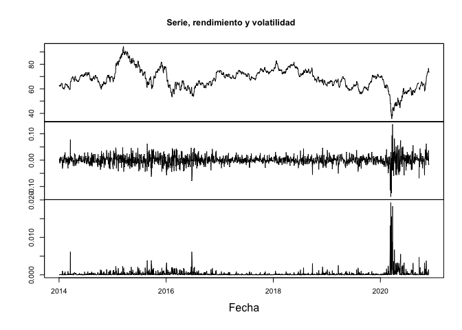

```r
plot.zoo(cbind(Ad(s_bmw),ren_bmw,ren_bmw^2), main = 'Serie, rendimiento y volatilidad', ylab = '', xlab = 'Fecha')
```

Realizamos el siguiente test para comprobar, si como dice la teoria, la media de la rentabilidad es 0. Obtenemos un p-valor igual a 0.8 por lo que no rechazamos que la media sea 0.

```r
t.test(ren_bmw) # no rechazamos media = 0
```

```
##
##  One Sample t-test
##
## data:  ren_bmw
## t = 0.21196, df = 1748, p-value = 0.8322
## alternative hypothesis: true mean is not equal to 0
## 95 percent confidence interval:
##  -0.0007406791  0.0009201661
## sample estimates:
##   mean of x
## 8.97435e-05
```

Generamos la serie temporal de la volatilidad de la rentabilidad de BMW para observar su correlograma y comprobar si es un ruido blanco. Tanto en el grafico, como en el test a 40 retardos, se puede verificar que la serie de volatilidad no es ruido blanco, lo que significa que la varinza de la serie de la rentabilidad de BMW no es constante.

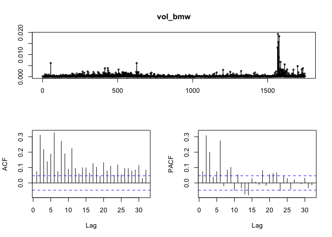

```r
vol_bmw <- ren_bmw^2
tsdisplay(vol_bmw) # vemos que la volatilidad no es ruido blanco
```

```r
Box.test(vol_bmw, lag=40, type="Lj")
```

```
##
##  Box-Ljung test
##
## data:  vol_bmw
## X-squared = 1230.8, df = 40, p-value < 2.2e-16
```

Con el test de Lagrange obtenemos la conclusión de que la serie de rentabilidad de BMW si presenta efectos GARCH, por lo que será necesario estimar un modelo de heteroscedasticidad condicionada.

```r
# Definomos la funcion del test
T.Lag <- function(r,m){
  y = (r - mean(r))^2
  t = length(r)
  a = y [(m +1) : t]
  x = matrix(0, (t - m), m)
  for (i in 1:m){
    x[,i] = y [(m+1-i):(t-i)]
  }
  md = lm(a~x)
  summary(md)
}

T.Lag(ren_bmw, m = 20) # rechazamos la H0 de que no hay efectos GARCH
```

```
##
## Call:
## lm(formula = a ~ x)
##
## Residuals:
##        Min         1Q     Median         3Q        Max
## -0.0047684 -0.0002218 -0.0001073  0.0000544  0.0181166
##
## Coefficients:
##               Estimate Std. Error t value Pr(>|t|)
## (Intercept)  9.000e-05  2.557e-05   3.519 0.000444 ***
## x1          -3.635e-02  2.416e-02  -1.505 0.132576
## x2           2.366e-01  2.417e-02   9.787  < 2e-16 ***
## x3           9.265e-02  2.479e-02   3.738 0.000192 ***
## x4          -1.179e-02  2.490e-02  -0.474 0.635720
## x5           8.426e-02  2.489e-02   3.386 0.000726 ***
## x6           2.478e-01  2.497e-02   9.921  < 2e-16 ***
## x7          -2.280e-02  2.559e-02  -0.891 0.373151
## x8           1.235e-01  2.552e-02   4.839 1.42e-06 ***
## x9           7.497e-02  2.568e-02   2.919 0.003553 **
## x10         -4.162e-02  2.568e-02  -1.621 0.105223
## x11          7.900e-02  2.568e-02   3.076 0.002130 **
## x12         -4.406e-02  2.569e-02  -1.715 0.086478 .
## x13         -8.408e-02  2.554e-02  -3.291 0.001017 **
## x14         -8.908e-02  2.562e-02  -3.476 0.000521 ***
## x15          1.820e-02  2.511e-02   0.725 0.468544
## x16         -1.169e-02  2.503e-02  -0.467 0.640494
## x17         -7.626e-03  2.503e-02  -0.305 0.760654
## x18          6.754e-02  2.492e-02   2.710 0.006793 **
## x19         -1.440e-02  2.431e-02  -0.592 0.553891
## x20          5.537e-02  2.430e-02   2.278 0.022826 *
## ---
## Signif. codes:  0 '***' 0.001 '**' 0.01 '*' 0.05 '.' 0.1 ' ' 1
##
## Residual standard error: 0.0008736 on 1708 degrees of freedom
## Multiple R-squared:  0.2415, Adjusted R-squared:  0.2326
## F-statistic: 27.19 on 20 and 1708 DF,  p-value: < 2.2e-16
```

El primer modelo que estimamos para corregir la heteroscedasticidad de la varianza es una GARCH(1,1), es decir, definimos la varinza del modelo en funcion de un retardo de la propia varinza y un retardo del error del modelo.

Al estimar dicho modelo, ademas de no distribuirse los errores como una normal, seguimos teniendo efectos GARCh por lo que debemos plantera otro modelo.

Realizamos el correlograma de los resiudos al cuadrado y observamos que son un ruido blanco. Y con el gráfico QQ-plot vemos que no es una normal, lo que solventaremos en la estimacion del proximo modelo

```r
m_garch =garchFit(~1+garch(1,1), data=ren_bmw, trace=F)
summary(m_garch)
```

```
##
## Title:
##  GARCH Modelling
##
## Call:
##  garchFit(formula = ~1 + garch(1, 1), data = ren_bmw, trace = F)
##
## Mean and Variance Equation:
##  data ~ 1 + garch(1, 1)
## <environment: 0x7f87aa9fb2e8>
##  [data = ren_bmw]
##
## Conditional Distribution:
##  norm
##
## Coefficient(s):
##         mu       omega      alpha1       beta1
## 3.0532e-04  2.5007e-06  4.9894e-02  9.4273e-01
##
## Std. Errors:
##  based on Hessian
##
## Error Analysis:
##         Estimate  Std. Error  t value Pr(>|t|)
## mu     3.053e-04   3.360e-04    0.909   0.3635
## omega  2.501e-06   9.781e-07    2.557   0.0106 *
## alpha1 4.989e-02   8.002e-03    6.235  4.5e-10 ***
## beta1  9.427e-01   9.548e-03   98.734  < 2e-16 ***
## ---
## Signif. codes:  0 '***' 0.001 '**' 0.01 '*' 0.05 '.' 0.1 ' ' 1
##
## Log Likelihood:
##  4799.462    normalized:  2.744118
##
## Description:
##  Mon Nov 30 18:31:15 2020 by user:
##
##
## Standardised Residuals Tests:
##                                 Statistic p-Value
##  Jarque-Bera Test   R    Chi^2  749.4246  0
##  Shapiro-Wilk Test  R    W      0.9722568 0
##  Ljung-Box Test     R    Q(10)  21.9004   0.01562014
##  Ljung-Box Test     R    Q(15)  26.40683  0.03395787
##  Ljung-Box Test     R    Q(20)  32.28662  0.04033832
##  Ljung-Box Test     R^2  Q(10)  21.35063  0.01877703
##  Ljung-Box Test     R^2  Q(15)  22.86262  0.08710055
##  Ljung-Box Test     R^2  Q(20)  26.26798  0.1571427
##  LM Arch Test       R    TR^2   21.86675  0.03904063
##
## Information Criterion Statistics:
##       AIC       BIC       SIC      HQIC
## -5.483661 -5.471159 -5.483672 -5.479039
```

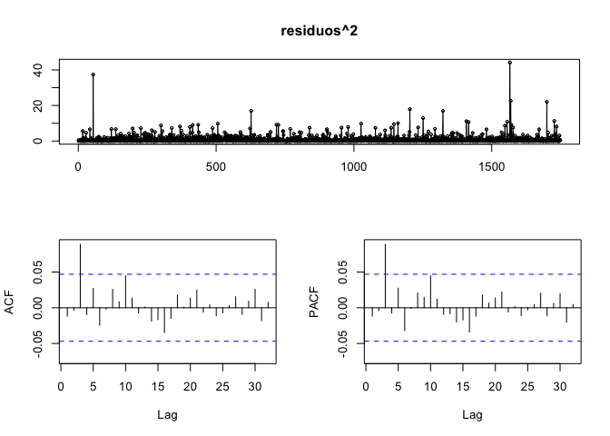

```r
residuos=residuals(m_garch,standardize=T) #residuals
residuos=xts(residuos, order.by=index(ren_bmw)) #residuals as xts
tsdisplay(residuos^2)
```

```r
Box.test(residuos^2, lag=40, type="Lj")
```

```
##
##  Box-Ljung test
##
## data:  residuos^2
## X-squared = 32.469, df = 40, p-value = 0.7955
```

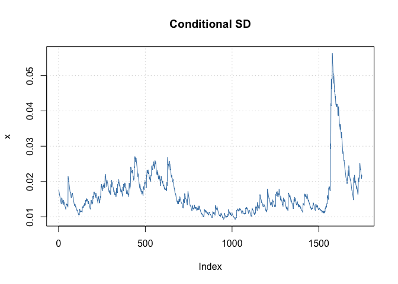

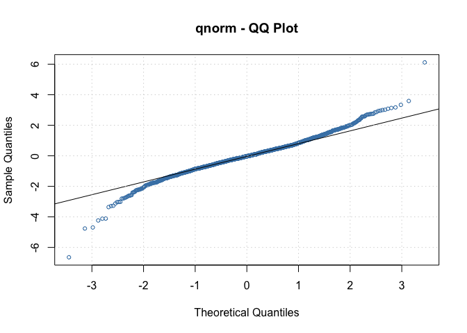

```r
plot(m_garch, which = c(2,13,0))
```

```r
m_garch2 =garchFit(~1+garch(1,2), data=ren_bmw, trace=F)
summary(m_garch2)
```

```
##
## Title:
##  GARCH Modelling
##
## Call:
##  garchFit(formula = ~1 + garch(1, 2), data = ren_bmw, trace = F)
##
## Mean and Variance Equation:
##  data ~ 1 + garch(1, 2)
## <environment: 0x7f87a90547b8>
##  [data = ren_bmw]
##
## Conditional Distribution:
##  norm
##
## Coefficient(s):
##         mu       omega      alpha1       beta1       beta2
## 3.4216e-04  3.5784e-06  7.7461e-02  3.3048e-01  5.8200e-01
##
## Std. Errors:
##  based on Hessian
##
## Error Analysis:
##         Estimate  Std. Error  t value Pr(>|t|)
## mu     3.422e-04   3.361e-04    1.018 0.308661
## omega  3.578e-06   1.454e-06    2.461 0.013837 *
## alpha1 7.746e-02   1.372e-02    5.648 1.63e-08 ***
## beta1  3.305e-01   1.796e-01    1.840 0.065714 .
## beta2  5.820e-01   1.730e-01    3.364 0.000768 ***
## ---
## Signif. codes:  0 '***' 0.001 '**' 0.01 '*' 0.05 '.' 0.1 ' ' 1
##
## Log Likelihood:
##  4799.502    normalized:  2.744141
##
## Description:
##  Mon Nov 30 18:31:15 2020 by user:
##
##
## Standardised Residuals Tests:
##                                 Statistic p-Value
##  Jarque-Bera Test   R    Chi^2  712.4504  0
##  Shapiro-Wilk Test  R    W      0.9729166 0
##  Ljung-Box Test     R    Q(10)  21.27659  0.01924532
##  Ljung-Box Test     R    Q(15)  26.03234  0.03768416
##  Ljung-Box Test     R    Q(20)  31.90182  0.04435575
##  Ljung-Box Test     R^2  Q(10)  18.48265  0.04734768
##  Ljung-Box Test     R^2  Q(15)  19.90858  0.1754679
##  Ljung-Box Test     R^2  Q(20)  23.36449  0.2712538
##  LM Arch Test       R    TR^2   18.62491  0.09799154
##
## Information Criterion Statistics:
##       AIC       BIC       SIC      HQIC
## -5.482564 -5.466936 -5.482580 -5.476787
```

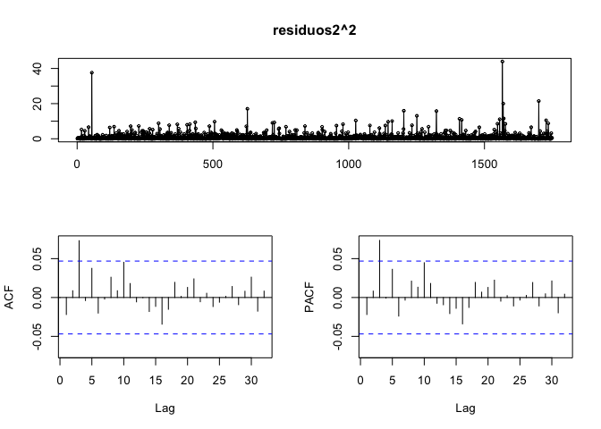

```r
residuos2=residuals(m_garch2,standardize=T) #residuals
residuos2=xts(residuos2, order.by=index(ren_bmw)) #residuals as xts
tsdisplay(residuos2^2)
```

```r
Box.test(residuos2^2, lag=40, type="Lj")
```

```
##
##  Box-Ljung test
##
## data:  residuos2^2
## X-squared = 29.534, df = 40, p-value = 0.8878
```

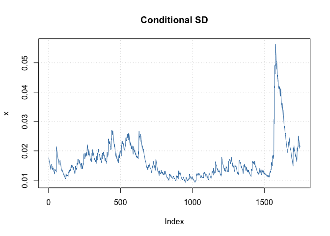

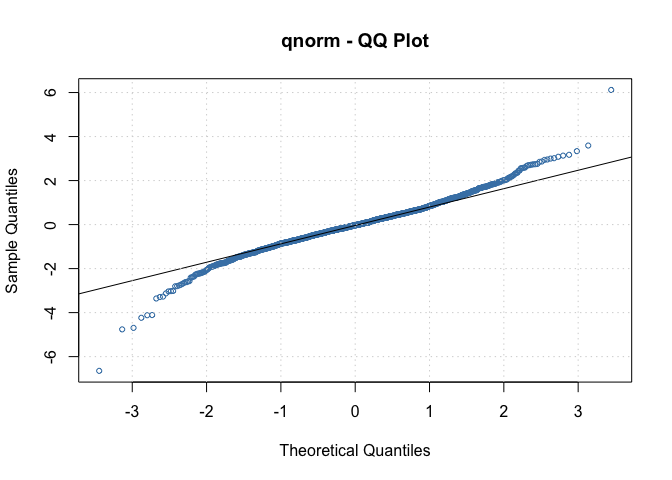

```r
plot(m_garch, which = c(2,13,0))
```

Una vez que tenemos estimado un modelo sin efectos GARCH pasamos a la prediccion de la rentabilidad de la serie. Solo hemos cogido 100 datos y hemos construido un IC al 90%, lo importante no es la predicción puntual si no si nos encontramos fuera o dentro de los intervalos.

```r
predict(m_garch2)
```

```
##    meanForecast  meanError standardDeviation
## 1  0.0003421647 0.02084435        0.02084435
## 2  0.0003421647 0.02134937        0.02134937
## 3  0.0003421647 0.02103305        0.02103305
## 4  0.0003421647 0.02119721        0.02119721
## 5  0.0003421647 0.02107955        0.02107955
## 6  0.0003421647 0.02112707        0.02112707
## 7  0.0003421647 0.02107786        0.02107786
## 8  0.0003421647 0.02108544        0.02108544
## 9  0.0003421647 0.02105986        0.02105986
## 10 0.0003421647 0.02105384        0.02105384
```

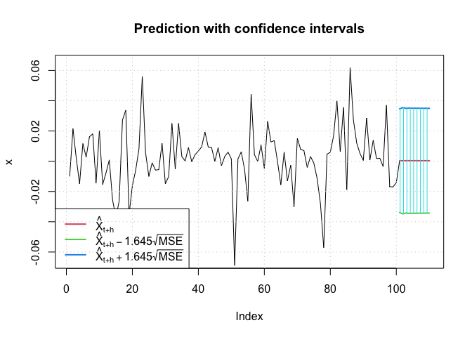

```
##    meanForecast  meanError standardDeviation lowerInterval upperInterval
## 1  0.0003421647 0.02084435        0.02084435   -0.03394374    0.03462807
## 2  0.0003421647 0.02134937        0.02134937   -0.03477442    0.03545875
## 3  0.0003421647 0.02103305        0.02103305   -0.03425412    0.03493845
## 4  0.0003421647 0.02119721        0.02119721   -0.03452415    0.03520847
## 5  0.0003421647 0.02107955        0.02107955   -0.03433061    0.03501494
## 6  0.0003421647 0.02112707        0.02112707   -0.03440877    0.03509310
## 7  0.0003421647 0.02107786        0.02107786   -0.03432782    0.03501215
## 8  0.0003421647 0.02108544        0.02108544   -0.03434030    0.03502463
## 9  0.0003421647 0.02105986        0.02105986   -0.03429822    0.03498255
## 10 0.0003421647 0.02105384        0.02105384   -0.03428831    0.03497264
```

```r
predict(m_garch2, n.ahead = 10, plot=TRUE, conf = .9, nx=100)
```

## Modelo VAR

El objetivo de este apartado es generar un modelo VAR de las series de rendimientos diarios de BMW y VOLKSWAGEN. Para ello, generamos primeros un dataframe con los rendiemientos diarios de ambos activos.

```r
ren_vol <- dailyReturn(s_vol)
df_ren <- cbind(ren_bmw, ren_vol)
df_ren <- na.omit(df_ren)
colnames(df_ren)=c("BMW","VOL")
```

Después realizamos un gráfico para seguir la evolucion del valor de los dos activos y sus rendimientos

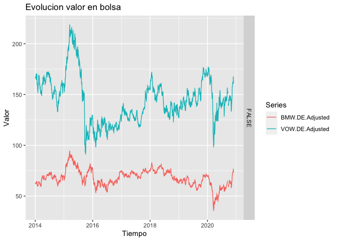

```r
df <- cbind(s_bmw, s_vol)

autoplot(df, facets = FALSE) +
  ggtitle("Evolucion valor en bolsa") +
  xlab("Tiempo") +
  ylab("Valor")
```

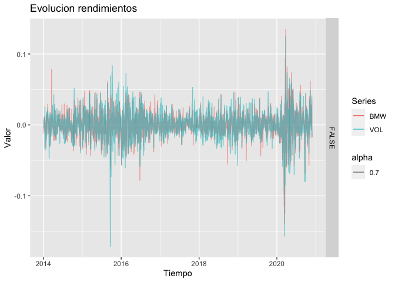

```r
autoplot(df_ren, alpha = 0.7, facets = FALSE) +
  ggtitle("Evolucion rendimientos") +
  xlab("Tiempo") +
  ylab("Valor")
```

El modelo VAR estimado presenta parametros estadisticamente significativos al 90% de confinza, los siguientes pasos será ver si las predicciones que realizan son adecuadas.

```r
m_var <- VAR(df_ren)
summary(m_var) # hay una significativa
```

```
##
## VAR Estimation Results:
## =========================
## Endogenous variables: BMW, VOL
## Deterministic variables: const
## Sample size: 1748
## Log Likelihood: 9682.731
## Roots of the characteristic polynomial:
## 0.05349 0.0449
## Call:
## VAR(y = df_ren)
##
##
## Estimation results for equation BMW:
## ====================================
## BMW = BMW.l1 + VOL.l1 + const
##
##          Estimate Std. Error t value Pr(>|t|)
## BMW.l1 -6.782e-02  3.667e-02  -1.850 0.064534 .
## VOL.l1  1.105e-01  3.237e-02   3.413 0.000657 ***
## const   7.289e-05  4.223e-04   0.173 0.862990
## ---
## Signif. codes:  0 '***' 0.001 '**' 0.01 '*' 0.05 '.' 0.1 ' ' 1
##
##
## Residual standard error: 0.01766 on 1745 degrees of freedom
## Multiple R-Squared: 0.007367,    Adjusted R-squared: 0.006229
## F-statistic: 6.475 on 2 and 1745 DF,  p-value: 0.001579
##
##
## Estimation results for equation VOL:
## ====================================
## VOL = BMW.l1 + VOL.l1 + const
##
##          Estimate Std. Error t value Pr(>|t|)
## BMW.l1 -0.0251778  0.0416106  -0.605   0.5452
## VOL.l1  0.0764186  0.0367291   2.081   0.0376 *
## const   0.0001720  0.0004793   0.359   0.7197
## ---
## Signif. codes:  0 '***' 0.001 '**' 0.01 '*' 0.05 '.' 0.1 ' ' 1
##
##
## Residual standard error: 0.02004 on 1745 degrees of freedom
## Multiple R-Squared: 0.003754,    Adjusted R-squared: 0.002612
## F-statistic: 3.288 on 2 and 1745 DF,  p-value: 0.03758
##
##
##
## Covariance matrix of residuals:
##           BMW       VOL
## BMW 0.0003117 0.0002684
## VOL 0.0002684 0.0004015
##
## Correlation matrix of residuals:
##        BMW    VOL
## BMW 1.0000 0.7587
## VOL 0.7587 1.0000
```

```r
causality(m_var) # rechazamos, puede haber bidericcionalidad
```

```
## $Granger
##
##  Granger causality H0: BMW do not Granger-cause VOL
##
## data:  VAR object m_var
## F-Test = 0.36612, df1 = 1, df2 = 3490, p-value = 0.5452
##
##
## $Instant
##
##  H0: No instantaneous causality between: BMW and VOL
##
## data:  VAR object m_var
## Chi-squared = 638.64, df = 1, p-value < 2.2e-16
```

Por otro lado, un impuslo positivo en Volkswagen genera una respuesta positiva en en perido posterior en BMW, y nada en periodos posteriores.

```r
shock_m_var <- irf(m_var)
shock_m_var
```

```
##
## Impulse response coefficients
## $BMW
##                BMW          VOL
##  [1,] 1.765640e-02 1.520290e-02
##  [2,] 4.818502e-04 7.172350e-04
##  [3,] 4.654672e-05 4.267816e-05
##  [4,] 1.557419e-06 2.089461e-06
##  [5,] 1.251777e-07 1.204613e-07
##  [6,] 4.816577e-09 6.053787e-09
##  [7,] 3.420407e-10 3.413511e-10
##  [8,] 1.450837e-11 1.747374e-11
##  [9,] 9.461903e-13 9.700299e-13
## [10,] 4.297869e-14 5.030534e-14
## [11,] 2.641908e-15 2.762154e-15
```

[output cut: 74 more lines]

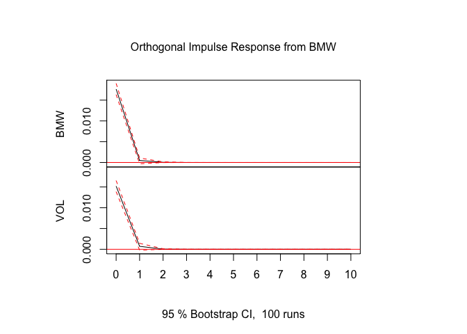

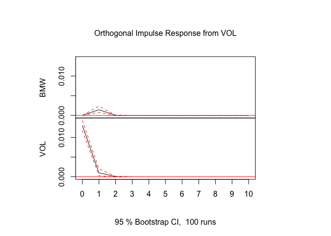

```r
plot(shock_m_var)
```

Por último, calculamos las predicciones de nuestro modelo VAR, aunque como observamos no son muy buenas ya que todas son valores muy proximos a 0.

```r
predict(m_var, n.ahead = 8, ci = 0.95, plot = T)
```

```
## $BMW
##              fcst       lower      upper         CI
## [1,] 7.827593e-05 -0.03452762 0.03468418 0.03460590
## [2,] 5.306615e-05 -0.03468085 0.03478698 0.03473392
## [3,] 8.696923e-05 -0.03464707 0.03482101 0.03473404
## [4,] 8.720018e-05 -0.03464684 0.03482124 0.03473404
## [5,] 8.728358e-05 -0.03464676 0.03482133 0.03473404
## [6,] 8.728486e-05 -0.03464676 0.03482133 0.03473404
## [7,] 8.728507e-05 -0.03464676 0.03482133 0.03473404
## [8,] 8.728507e-05 -0.03464676 0.03482133 0.03473404
##
## $VOL
##               fcst       lower      upper         CI
## [1,] -0.0001314197 -0.03940315 0.03914031 0.03927173
## [2,]  0.0001600268 -0.03918545 0.03950551 0.03934548
## [3,]  0.0001829334 -0.03916271 0.03952858 0.03934565
## [4,]  0.0001838303 -0.03916182 0.03952948 0.03934565
## [5,]  0.0001838931 -0.03916176 0.03952954 0.03934565
## [6,]  0.0001838958 -0.03916175 0.03952954 0.03934565
## [7,]  0.0001838959 -0.03916175 0.03952954 0.03934565
## [8,]  0.0001838959 -0.03916175 0.03952954 0.03934565
```